# 2-Feature-Transformation-Dimentionality-Reduction

#### Importing libraries

```python
%store -r azdias_cleaned
```

```python
import numpy as np
import pandas as pd
import matplotlib.pyplot as plt
import seaborn as sns

from sklearn.preprocessing import StandardScaler
from sklearn.decomposition import PCA
from sklearn.cluster import KMeans

from collections import OrderedDict

import ast

# magic word for producing visualizations in notebook
%matplotlib inline
```

```python
azdias_cleaned.head()
```

|  | ALTERSKATEGORIE_GROB | ANREDE_KZ | FINANZ_MINIMALIST | FINANZ_SPARER | FINANZ_VORSORGER | FINANZ_ANLEGER | FINANZ_UNAUFFAELLIGER | FINANZ_HAUSBAUER | GREEN_AVANTGARDE | HEALTH_TYP | ... | WEALTH_Comfortable Households | WEALTH_Less Affluent Households | WEALTH_Poorer Households | WEALTH_Prosperous Households | WEALTH_Wealthy Households | LIFE_STAGE_Elders In Retirement | LIFE_STAGE_Families With School Age Children | LIFE_STAGE_Older Families & Mature Couples | LIFE_STAGE_Pre-Family Couples & Singles | LIFE_STAGE_Young Couples With Children |
| --- | --- | --- | --- | --- | --- | --- | --- | --- | --- | --- | --- | --- | --- | --- | --- | --- | --- | --- | --- | --- | --- |
| 1 | 1.0 | 2 | 1 | 5 | 2 | 5 | 4 | 5 | 0 | 3.0 | ... | 0 | 0 | 1 | 0 | 0 | 0 | 0 | 0 | 1 | 0 |
| 2 | 3.0 | 2 | 1 | 4 | 1 | 2 | 3 | 5 | 1 | 3.0 | ... | 0 | 0 | 0 | 1 | 0 | 0 | 0 | 1 | 0 | 0 |
| 3 | 4.0 | 2 | 4 | 2 | 5 | 2 | 1 | 2 | 0 | 2.0 | ... | 0 | 0 | 0 | 0 | 1 | 0 | 0 | 0 | 0 | 1 |
| 4 | 3.0 | 1 | 4 | 3 | 4 | 1 | 3 | 2 | 0 | 3.0 | ... | 0 | 1 | 0 | 0 | 0 | 0 | 1 | 0 | 0 | 0 |
| 5 | 1.0 | 2 | 3 | 1 | 5 | 2 | 2 | 5 | 0 | 3.0 | ... | 0 | 0 | 1 | 0 | 0 | 0 | 0 | 1 | 0 | 0 |

5 rows × 209 columns

## Step 2: Feature Transformation

### Step 2.1: Apply Feature Scaling

Before we apply dimensionality reduction techniques to the data, we need to perform feature scaling so that the principal component vectors are not influenced by the natural differences in scale for features. Starting from this part of the project, we'll want to keep an eye on the [API reference page for sklearn](http://scikit-learn.org/stable/modules/classes.html) to help us navigate to all of the classes and functions that we'll need. In this substep, we'll need to check the following:

- sklearn requires that data not have missing values in order for its estimators to work properly. So, before applying the scaler to your data, make sure that you've cleaned the DataFrame of the remaining missing values. This can be as simple as just removing all data points with missing data, or applying an [Imputer](http://scikit-learn.org/stable/modules/generated/sklearn.preprocessing.Imputer.html) to replace all missing values. You might also try a more complicated procedure where you temporarily remove missing values in order to compute the scaling parameters before re-introducing those missing values and applying imputation. Think about how much missing data you have and what possible effects each approach might have on your analysis, and justify your decision in the discussion section below.
- For the actual scaling function, a [StandardScaler](http://scikit-learn.org/stable/modules/generated/sklearn.preprocessing.StandardScaler.html) instance is suggested, scaling each feature to mean 0 and standard deviation 1.
- For these classes, you can make use of the `.fit_transform()` method to both fit a procedure to the data as well as apply the transformation to the data at the same time. Don't forget to keep the fit sklearn objects handy, since you'll be applying them to the customer demographics data towards the end of the project.

```python
# Investigate all nans are removed
azdias_cleaned.info()
```

```
<class 'pandas.core.frame.DataFrame'>
Int64Index: 797837 entries, 1 to 891220
Columns: 209 entries, ALTERSKATEGORIE_GROB to LIFE_STAGE_Young Couples With Children
dtypes: float64(41), int64(23), uint8(145)
memory usage: 506.0 MB
```

```python
from sklearn.preprocessing import Imputer
from sklearn.preprocessing import StandardScaler
scale = StandardScaler()
imp = Imputer(missing_values=float("NaN"), strategy="mean", axis=1, copy = False)

azdias_cleaned[azdias_cleaned.columns] = scale.fit_transform(imp.fit_transform(azdias_cleaned))
```

```python
azdias_cleaned.head()
```

|  | ALTERSKATEGORIE_GROB | ANREDE_KZ | FINANZ_MINIMALIST | FINANZ_SPARER | FINANZ_VORSORGER | FINANZ_ANLEGER | FINANZ_UNAUFFAELLIGER | FINANZ_HAUSBAUER | GREEN_AVANTGARDE | HEALTH_TYP | ... | WEALTH_Comfortable Households | WEALTH_Less Affluent Households | WEALTH_Poorer Households | WEALTH_Prosperous Households | WEALTH_Wealthy Households | LIFE_STAGE_Elders In Retirement | LIFE_STAGE_Families With School Age Children | LIFE_STAGE_Older Families & Mature Couples | LIFE_STAGE_Pre-Family Couples & Singles | LIFE_STAGE_Young Couples With Children |
| --- | --- | --- | --- | --- | --- | --- | --- | --- | --- | --- | --- | --- | --- | --- | --- | --- | --- | --- | --- | --- | --- |
| 1 | -1.512375 | 0.957932 | -1.494575 | 1.537983 | -1.040685 | 1.466063 | 0.958965 | 1.339139 | -0.53045 | 0.107134 | ... | -0.305667 | -0.559009 | 1.602672 | -0.560324 | -0.419567 | -0.414613 | -0.420054 | -0.641785 | 1.501998 | -0.327505 |
| 2 | 0.136690 | 0.957932 | -1.494575 | 0.864621 | -1.766949 | -0.570955 | 0.244386 | 1.339139 | 1.88519 | 0.107134 | ... | -0.305667 | -0.559009 | -0.623958 | 1.784682 | -0.419567 | -0.414613 | -0.420054 | 1.558153 | -0.665780 | -0.327505 |
| 3 | 0.961223 | 0.957932 | 0.683195 | -0.482102 | 1.138107 | -0.570955 | -1.184772 | -0.791524 | -0.53045 | -0.286092 | ... | -0.305667 | -0.559009 | -0.623958 | -0.560324 | 2.383412 | -0.414613 | -0.420054 | -0.641785 | -0.665780 | 3.053388 |
| 4 | 0.136690 | -1.043916 | 0.683195 | 0.191259 | 0.411843 | -1.249961 | 0.244386 | -0.791524 | -0.53045 | 0.107134 | ... | -0.305667 | 1.788880 | -0.623958 | -0.560324 | -0.419567 | -0.414613 | 2.380646 | -0.641785 | -0.665780 | -0.327505 |
| 5 | -1.512375 | 0.957932 | -0.042728 | -1.155464 | 1.138107 | -0.570955 | -0.470193 | 1.339139 | -0.53045 | 0.107134 | ... | -0.305667 | -0.559009 | 1.602672 | -0.560324 | -0.419567 | -0.414613 | -0.420054 | 1.558153 | -0.665780 | -0.327505 |

5 rows × 209 columns

```python
azdias_cleaned.describe()
```

|  | ALTERSKATEGORIE_GROB | ANREDE_KZ | FINANZ_MINIMALIST | FINANZ_SPARER | FINANZ_VORSORGER | FINANZ_ANLEGER | FINANZ_UNAUFFAELLIGER | FINANZ_HAUSBAUER | GREEN_AVANTGARDE | HEALTH_TYP | ... | WEALTH_Comfortable Households | WEALTH_Less Affluent Households | WEALTH_Poorer Households | WEALTH_Prosperous Households | WEALTH_Wealthy Households | LIFE_STAGE_Elders In Retirement | LIFE_STAGE_Families With School Age Children | LIFE_STAGE_Older Families & Mature Couples | LIFE_STAGE_Pre-Family Couples & Singles | LIFE_STAGE_Young Couples With Children |
| --- | --- | --- | --- | --- | --- | --- | --- | --- | --- | --- | --- | --- | --- | --- | --- | --- | --- | --- | --- | --- | --- |
| count | 7.978370e+05 | 7.978370e+05 | 7.978370e+05 | 7.978370e+05 | 7.978370e+05 | 7.978370e+05 | 7.978370e+05 | 7.978370e+05 | 7.978370e+05 | 7.978370e+05 | ... | 7.978370e+05 | 7.978370e+05 | 7.978370e+05 | 7.978370e+05 | 7.978370e+05 | 7.978370e+05 | 7.978370e+05 | 7.978370e+05 | 7.978370e+05 | 7.978370e+05 |
| mean | 6.428613e-15 | -1.588355e-15 | -3.205966e-15 | 3.250555e-16 | -1.942080e-14 | 1.615614e-14 | 3.600112e-16 | -3.439685e-15 | -3.501526e-14 | -8.170621e-15 | ... | -1.600662e-14 | 7.139901e-15 | -3.143152e-14 | 4.656601e-15 | 5.486927e-15 | 3.165115e-14 | -1.386980e-14 | -4.200967e-15 | -3.654210e-15 | 4.505116e-15 |
| std | 1.000001e+00 | 1.000001e+00 | 1.000001e+00 | 1.000001e+00 | 1.000001e+00 | 1.000001e+00 | 1.000001e+00 | 1.000001e+00 | 1.000001e+00 | 1.000001e+00 | ... | 1.000001e+00 | 1.000001e+00 | 1.000001e+00 | 1.000001e+00 | 1.000001e+00 | 1.000001e+00 | 1.000001e+00 | 1.000001e+00 | 1.000001e+00 | 1.000001e+00 |
| min | -1.512375e+00 | -1.043916e+00 | -1.494575e+00 | -1.155464e+00 | -1.766949e+00 | -1.249961e+00 | -1.184772e+00 | -1.501745e+00 | -5.304505e-01 | -6.793171e-01 | ... | -3.056668e-01 | -5.590089e-01 | -6.239578e-01 | -5.603240e-01 | -4.195666e-01 | -4.146132e-01 | -4.200540e-01 | -6.417854e-01 | -6.657797e-01 | -3.275051e-01 |
| 25% | -6.878427e-01 | -1.043916e+00 | -7.686517e-01 | -1.155464e+00 | -1.040685e+00 | -1.249961e+00 | -1.184772e+00 | -7.915240e-01 | -5.304505e-01 | -2.860917e-01 | ... | -3.056668e-01 | -5.590089e-01 | -6.239578e-01 | -5.603240e-01 | -4.195666e-01 | -4.146132e-01 | -4.200540e-01 | -6.417854e-01 | -6.657797e-01 | -3.275051e-01 |
| 50% | 1.366901e-01 | 9.579317e-01 | -4.272814e-02 | 1.912594e-01 | 4.118430e-01 | 1.080512e-01 | -4.701931e-01 | -8.130308e-02 | -5.304505e-01 | -2.860917e-01 | ... | -3.056668e-01 | -5.590089e-01 | -6.239578e-01 | -5.603240e-01 | -4.195666e-01 | -4.146132e-01 | -4.200540e-01 | -6.417854e-01 | -6.657797e-01 | -3.275051e-01 |
| 75% | 9.612228e-01 | 9.579317e-01 | 6.831954e-01 | 8.646211e-01 | 1.138107e+00 | 7.870572e-01 | 9.589645e-01 | 6.289178e-01 | -5.304505e-01 | 1.071338e-01 | ... | -3.056668e-01 | -5.590089e-01 | 1.602672e+00 | -5.603240e-01 | -4.195666e-01 | -4.146132e-01 | -4.200540e-01 | 1.558153e+00 | 1.501998e+00 | -3.275051e-01 |
| max | 1.536225e+01 | 9.579317e-01 | 1.409119e+00 | 1.537983e+00 | 1.138107e+00 | 1.466063e+00 | 1.673543e+00 | 1.339139e+00 | 1.885190e+00 | 7.791826e+00 | ... | 3.271537e+00 | 1.788880e+00 | 1.602672e+00 | 1.784682e+00 | 2.383412e+00 | 2.411887e+00 | 2.380646e+00 | 1.558153e+00 | 1.501998e+00 | 3.053388e+00 |

8 rows × 209 columns

```python
azdias_cleaned.info()
```

```
<class 'pandas.core.frame.DataFrame'>
Int64Index: 797837 entries, 1 to 891220
Columns: 209 entries, ALTERSKATEGORIE_GROB to LIFE_STAGE_Young Couples With Children
dtypes: float64(209)
memory usage: 1.2 GB
```

### Discussion 2.1: Apply Feature Scaling

Imputer object help me to replace nans. I choose to apply mean for the replacement as it seems to me that it could contribute to a normalized dataset. I also instanciate a standardscalar to scale original columns to mhu 0 and sd to1.

### Step 2.2: Perform Dimensionality Reduction

On our scaled data, we are now ready to apply dimensionality reduction techniques.

- Use sklearn's [PCA](http://scikit-learn.org/stable/modules/generated/sklearn.decomposition.PCA.html) class to apply principal component analysis on the data, thus finding the vectors of maximal variance in the data. To start, you should not set any parameters (so all components are computed) or set a number of components that is at least half the number of features (so there's enough features to see the general trend in variability).
- Check out the ratio of variance explained by each principal component as well as the cumulative variance explained. Try plotting the cumulative or sequential values using matplotlib's [`plot()`](https://matplotlib.org/api/_as_gen/matplotlib.pyplot.plot.html) function. Based on what you find, select a value for the number of transformed features you'll retain for the clustering part of the project.
- Once you've made a choice for the number of components to keep, make sure you re-fit a PCA instance to perform the decided-on transformation.

```python
# Apply PCA to the data.
pca = PCA()
azdias_default_pca = pca.fit_transform(azdias_cleaned)
```

```python
# Investigate the variance accounted for by each principal component.
def pca_explained_variance(pca):
    # based on helpers from the nanodegree documents
    explained_variance = pca.explained_variance_ratio_
    explained_variance_accumulated = explained_variance.cumsum()
    x = range(1, len(pca.explained_variance_ratio_) + 1)

    plt.figure(figsize=(16, 8))
    plt.fill_between(x, explained_variance_accumulated, 0, color='#ddeeff')
    plt.bar(x, explained_variance, width=0.5, color='g', label='Variance explained by component')
    plt.plot(x, explained_variance_accumulated, label='Accumulated explained variance')
    plt.grid(True)
    plt.title('Variance explained by PCA components')
    plt.ylabel('Explained variance proportion')
    plt.xlabel('Feature')
    plt.legend()
    plt.show()
```

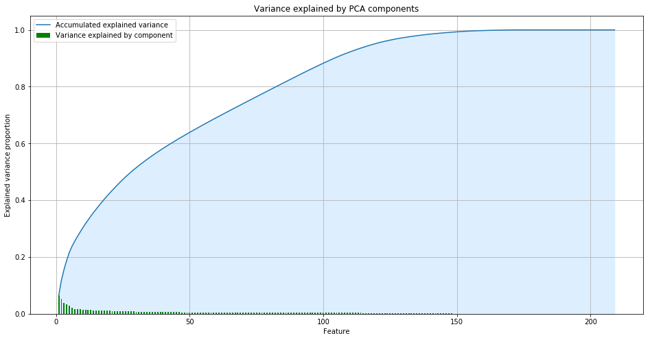

```python
pca_explained_variance(pca)
```

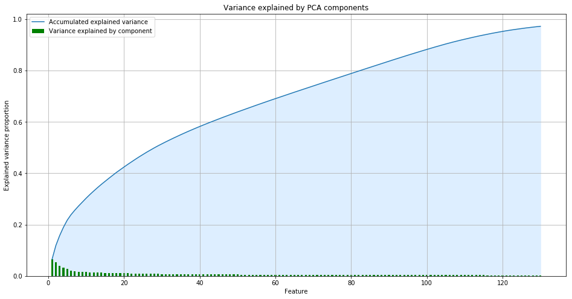

```python
# Re-apply PCA to the data while selecting for number of components to retain.
selected_pca = PCA(130)
selected_pca_transform = selected_pca.fit_transform(azdias_cleaned)
pca_explained_variance(selected_pca)
```

```python
selected_pca.explained_variance_ratio_.sum()
```

```
0.9727915558376004
```

```python
print('selected transformed pca data type:', type(selected_pca_transform)) # numpy array
print('selected transformed pca shape:', selected_pca_transform.shape) # data features per number of components selected: (792287, 130)
```

```
selected transformed pca data type: <class 'numpy.ndarray'>
selected transformed pca shape: (797837, 130)
```

### Discussion 2.2: Perform Dimensionality Reduction

Analizing the first graph it can be seen that around 130 features explain almost 100% data variance so at that point it is reasonable to reduce demensionality.

### Step 2.3: Interpret Principal Components

Now that we have our transformed principal components, it's a nice idea to check out the weight of each variable on the first few components to see if they can be interpreted in some fashion.

As a reminder, each principal component is a unit vector that points in the direction of highest variance (after accounting for the variance captured by earlier principal components). The further a weight is from zero, the more the principal component is in the direction of the corresponding feature. If two features have large weights of the same sign (both positive or both negative), then increases in one tend expect to be associated with increases in the other. To contrast, features with different signs can be expected to show a negative correlation: increases in one variable should result in a decrease in the other.

- To investigate the features, we should map each weight to their corresponding feature name, then sort the features according to weight. The most interesting features for each principal component, then, will be those at the beginning and end of the sorted list. Use the data dictionary document to help we understand these most prominent features, their relationships, and what a positive or negative value on the principal component might indicate.
- We should investigate and interpret feature associations from the first three principal components in this substep. To help facilitate this, we should write a function that we can call at any time to print the sorted list of feature weights, for the *i*-th principal component. This might come in handy in the next step of the project, when we interpret the tendencies of the discovered clusters.

```python
# Defining a function we can reuse.

def plot_features_proportion_per_pca_component(df, pca, nb_component, component_threshold):
    """
    Plotting X comonent weights over original features.
    """
    df_component = pd.DataFrame(pca.components_, columns=df.columns)
    row = pd.Series(df_component.iloc[nb_component - 1], index=df_component.columns)

    # removing components below threshold
    row = row[abs(row) > component_threshold]
    row = row.sort_values(ascending=False)

    # Create a bar plot visualization
    fig, ax = plt.subplots(figsize = (18,8))
    title = 'Feature proportions for component %s'%(nb_component)

    row.plot(ax = ax, kind='bar', title=title)
    plt.xlabel('Features with proportion above %s percent' %component_threshold)
    plt.ylabel('Feature proportion' )

    return row
```

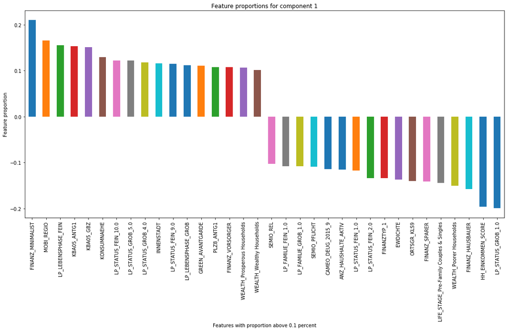

```python
# Map weights for the first principal component to corresponding feature names
# and then print the linked values, sorted by weight.
feature_label = 1
feature_proportion_threshold = 0.1
features_proportion_by_PCA_1 = plot_features_proportion_per_pca_component(
                                    azdias_cleaned,
                                    selected_pca,
                                    feature_label,
                                    feature_proportion_threshold
                                )
```

```python
features_proportion_by_PCA_1.head()
```

```
FINANZ_MINIMALIST      0.210302
MOBI_REGIO             0.165386
LP_LEBENSPHASE_FEIN    0.155614
KBA05_ANTG1            0.152837
KBA05_GBZ              0.151011
Name: 0, dtype: float64
```

```python
features_proportion_by_PCA_1.tail()
```

```
LIFE_STAGE_Pre-Family Couples & Singles   -0.144668
WEALTH_Poorer Households                  -0.150129
FINANZ_HAUSBAUER                          -0.157304
HH_EINKOMMEN_SCORE                        -0.196301
LP_STATUS_GROB_1.0                        -0.199577
Name: 0, dtype: float64
```

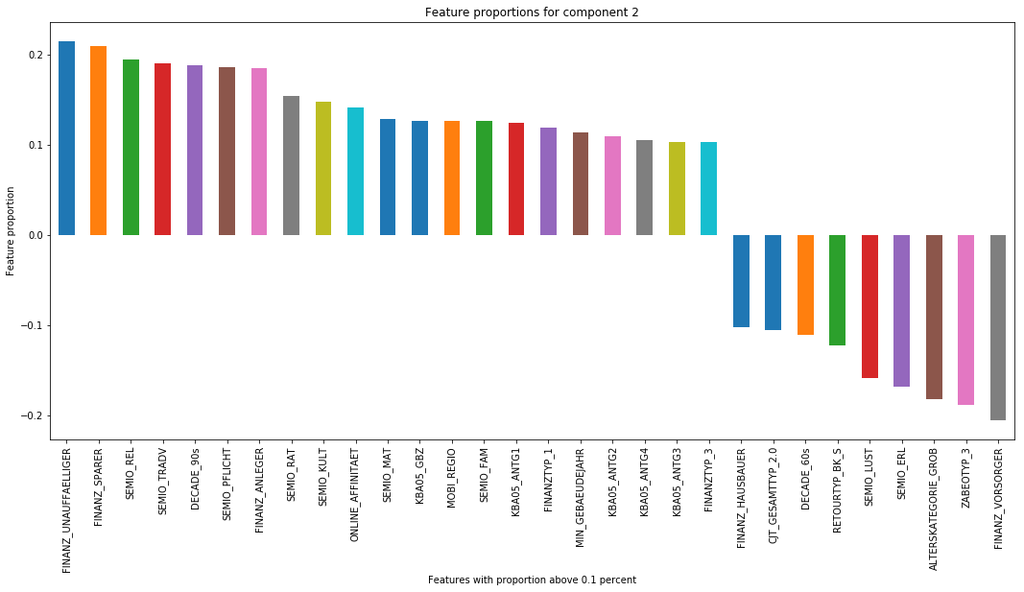

```python
# Map weights for the second principal component to corresponding feature names
# and then print the linked values, sorted by weight.
feature_label = 2
feature_proportion_threshold = 0.1
features_proportion_by_PCA_2 = plot_features_proportion_per_pca_component(
                                    azdias_cleaned,
                                    selected_pca,
                                    feature_label,
                                    feature_proportion_threshold
                                )
```

```python
features_proportion_by_PCA_2.head()
```

```
FINANZ_UNAUFFAELLIGER    0.215025
FINANZ_SPARER            0.209558
SEMIO_REL                0.195113
SEMIO_TRADV              0.190784
DECADE_90s               0.188049
Name: 1, dtype: float64
```

```python
features_proportion_by_PCA_2.tail()
```

```
SEMIO_LUST             -0.158014
SEMIO_ERL              -0.167735
ALTERSKATEGORIE_GROB   -0.181451
ZABEOTYP_3             -0.187946
FINANZ_VORSORGER       -0.205319
Name: 1, dtype: float64
```

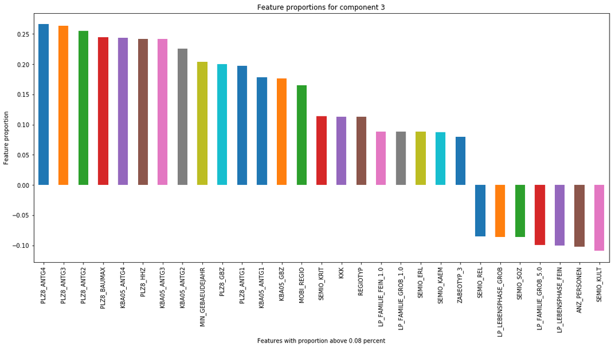

```python
# Map weights for the third principal component to corresponding feature names
# and then print the linked values, sorted by weight.
feature_label = 3
feature_proportion_threshold = 0.08
features_proportion_by_PCA_3 = plot_features_proportion_per_pca_component(
                                    azdias_cleaned,
                                    selected_pca,
                                    feature_label,
                                    feature_proportion_threshold
                                )
```

```python
features_proportion_by_PCA_3.head()
```

```
PLZ8_ANTG4     0.266157
PLZ8_ANTG3     0.263546
PLZ8_ANTG2     0.255079
PLZ8_BAUMAX    0.244720
KBA05_ANTG4    0.243518
Name: 2, dtype: float64
```

```python
features_proportion_by_PCA_3.tail()
```

```
SEMIO_SOZ             -0.086080
LP_FAMILIE_GROB_5.0   -0.099484
LP_LEBENSPHASE_FEIN   -0.100055
ANZ_PERSONEN          -0.101925
SEMIO_KULT            -0.108624
Name: 2, dtype: float64
```

### Discussion 2.3: Interpret Principal Components

The table bellow shows the higher weighted features per component.

- In the first component it can be seen the relation beetween LP_STATUS_GROB and HH_EINKOMMEN_SCORE bot related with income earnings. While MOBI_REGIO and FINANZ_MINIMALIST can be also related to income. This component seems to encapsule the **Income feature**.
- The second component is mearly defined by a **finantial feature**.
- The third component seems to be related with a **personality feature** since KBA05_ANTG4 and PLZ8_ANTG4 refer to where the individuos come from or where they were raised.

[output not shown]